# Linear Model 2

Robert C Cline Sr

2022-04-14

## Linear Model 2

We will use the *ilri.sheep* dataset, also from the agridat package.

**question**: Is the weight of lambs at weaning a function of their age at weaning?, with the hypothesis that lambs that are weaned later are also heavier.

year lamb sex gen birthwt weanwt weanage ewe ewegen damage ram ramgen 1 92 1060 F RR 1.9 9.4 105 5257 R 2 4902 R 2 92 1094 F DR 2.2 9.3 100 4812 R 2 4910 D 3 92 1099 F RR 2.4 8.4 100 4847 R 2 4918 R 4 92 1104 M RR 1.2 8.3 100 4870 R 2 4921 R 5 92 1118 M RR 2.6 10.0 98 4815 R 2 4905 R 6 92 1129 F RR 2.5 11.3 97 4845 R 2 4914 R

Call: lm(formula = weanwt ~ weanage, data = sheep)

Residuals: Min 1Q Median 3Q Max -5.5504 -1.1315 0.0518 1.1899 5.4250

Coefficients: Estimate Std. Error t value Pr(>|t|)  
(Intercept) 2.599514 0.892854 2.911 0.00389 ** weanage 0.079711 0.009499 8.392 2.4e-15 *** — Signif. codes: 0 ‘**’ 0.001 ’**’ 0.01 ’’ 0.05 ‘.’ 0.1 ’ ’ 1

Residual standard error: 1.963 on 280 degrees of freedom (56 observations deleted due to missingness) Multiple R-squared: 0.201, Adjusted R-squared: 0.1981 F-statistic: 70.42 on 1 and 280 DF, p-value: 2.397e-15

**Table 1.** Estimate is Intercept when lamb is 0 days old.

|  | weanwt |  |  |
| --- | --- | --- | --- |
| Predictors | Estimates | CI | p |
| (Intercept) | 2.60 | 0.84 – 4.36 | **0.004** |
| weanage | 0.08 | 0.06 – 0.10 | **<0.001** |
| Observations | 282 |  |  |
| R<sup>2</sup> / R<sup>2</sup> adjusted | 0.201 / 0.198 |  |  |

- $lamb weight = 2.60 + 0.08(age)$

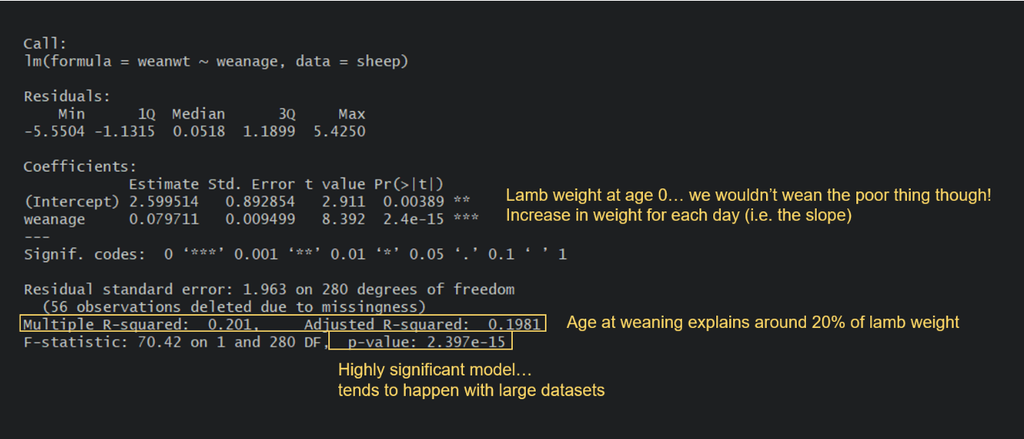

### Weanage accounts for only 20% of the weight at weaning. What if the sex of lamb influences weight gain?

Call: lm(formula = weanwt ~ weanage * sex, data = sheep)

Residuals: Min 1Q Median 3Q Max -5.7173 -1.1760 0.0179 1.2886 5.6429

Coefficients: Estimate Std. Error t value Pr(>|t|)  
(Intercept) 3.65829 1.24107 2.948 0.00347 ** weanage 0.06469 0.01308 4.946 1.31e-06 *** sexM -2.51878 1.76234 -1.429 0.15406  
weanage:sexM 0.03392 0.01874 1.810 0.07133 .  
— Signif. codes: 0 ‘**’ 0.001 ’**’ 0.01 ’’ 0.05 ‘.’ 0.1 ’ ’ 1

Residual standard error: 1.933 on 278 degrees of freedom (56 observations deleted due to missingness) Multiple R-squared: 0.2314, Adjusted R-squared: 0.2231 F-statistic: 27.9 on 3 and 278 DF, p-value: 8.446e-16

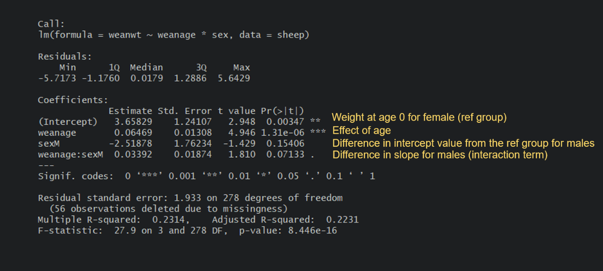

**Female weight = 3.66 + 0.06(age)** : The weight at 100 days would be 3.66 + 0.06(100) = 9.66 kg.

**Male weight = 3.66 + [-2.52] + 0.06(age) + [0.03(age)]** : The weight at 100 days would be 3.66 - 2.52 + (0.06+0.03)(100) = 10.14 kg.

### Visualize the data

- [Create *theme.clean*](https://ourcodingclub.github.io/tutorials/data-vis-2/index.html)

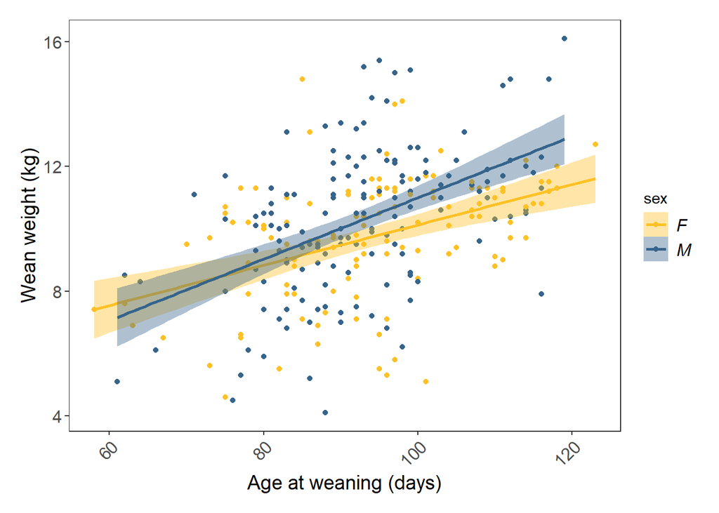